# Aula 1 - Introdução ao R

Vitor Rios

10 de outubro de 2017

# Bem vindos

## Cronograma

Dia 1 - 21/11 - Introdução e como usar o R e Rstudio, boas práticas de programação  
Dia 2 - 22/11 - Criando e e manipulando dados  
Dia 3 - 23/11 - Trabalhando com arquivos externos  
Dia 4 - 28/12 - Noções de programação  
Dia 5 - 05/12 - Gráficos  
Dia 6 - 06/12 - Análise exploratória e funções matemáticas  
Dia 7 - 07/12 - Análise exploratória e funções matemáticas  
Dia 8 - 12/12 - Análise estatística básica  
Dia 9 - 13/12 - Versionamento de código: noções de git  
Dia 10 - 14/12 - Programação para iniciantes, Função final

Aulas: teoria (1 a 2 h) + prática (wiki do curso) Avaliação: exercícios e constução de uma função (entrega 2 semanas após fim da disciplina)

Enviar exercícios para `cursolinguagemr@gmail.com`

# O que é o R?

- R é uma linguagem de programação voltada para análises estatísticas e manipulação de dados
- RStudio é um ambiente de desenvolvimento integrado (IDE) que extende as capacidades do R e facilita o uso

## Jeito R de ser

- Praticidade
- Reprodutibilidade
- Simplicidade (sim, você leu direito)
- Cooperação

Ao fazer o tratamento e análise dos dados dentro do R, você não altera os dados originais, e pode reproduzir tudo, bastando ter o script e os dados originais. Não é necessário nem salvar os gráficos!

# Porque Usar R?

- Uma vastidão de pacotes de análises prontas

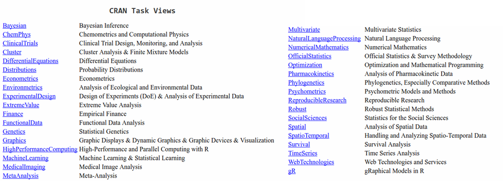

CranTaskView

- Além disso, o R tem **Interfaces amigáveis que não precisam de programação**
  - RCommander <- fácil acesso às análises principais
  - Action <- análises integradas ao Excel
  - RStudio <-ambiente completo de programação
- Possibilidade de programar suas próprias análises, de acordo com suas necessidades
- Integração com outros softwares
  - GIS
  - Git **<– Salvação da humanidade**
  - Excel
  - C++
  - Python
  - Esta aula foi feita em R no RStudio

# Primeiros passos no R

## Abrir o RStudio

[figure not shown]

# No RStudio

## Vantagens do RStudio

Note que o RStudio muda automaticamente as cores do código. Isto é chamado `syntax highlighting`, e serve pra facilitar a leitura. O que cada cor quer dizer?

O Rstudio também insere automaticamente um `)`, `}` ou `]` quando você digita `(`, `{`, ou `[`, o que diminui a maior parte dos erros de digitação

Digite o comando abaixo na aba console, onde está o caractere `>` , e depois tecle **enter**

```r
4 + 12
```

```
## [1] 16
```

O resultado aparece logo abaixo, na própria aba, em cor diferente

# O R é uma calculadora completa, tente várias combinações.

Qualquer texto após # é ignorado pelo R

```r
1 + 1  # soma
```

```
## [1] 2
```

```r
3 - 74 ## subtração
```

```
## [1] -71
```

```r
4 * 12 ## multiplicação
```

```
## [1] 48
```

```r
3 / 7 ## divisão
```

```
## [1] 0.4285714
```

# O R também aceita comandos mais complicados

```r
  pi ^ 2 # potência
```

```
## [1] 9.869604
```

```r
((4 * 7) + 45) / 2
```

```
## [1] 36.5
```

O que está dentro dos parênteses é avaliado de dentro para fora, e o resultado é usado para a operação seguinte, e assim por diante

# Logaritmos, exponenciações, raízes

```r
log(10, base=2)
```

```
## [1] 3.321928
```

```r
exp(1)
```

```
## [1] 2.718282
```

```r
sqrt(2)
```

```
## [1] 1.414214
```

# Funções

Quando temos um nome seguido de parêntese com alguma coisa dentro, temos uma **função**  
Função é um conjunto de comandos que faz uma operação em um objeto  
`sqrt(x)` calcula a raiz quadrada de x  
Funções podem ter opçoes, chamadas argumentos

```r
log(10, base=2)
```

calcula o logaritmo de 10 na base 2

Quase tudo que você vai usar no R são funções

Muito cuidado com a digitação: para o R, maiúsculas e minúsculas são diferentes, e um espaço no meio da palavra atrapalha tudo

**O R é burro, qualquer erro de digitação faz com que ele não encontre o que você procura**

# Ajuda das funções

você pode pedir socorro ao R em qualquer momento

```r
?log()
?exp()
?plot()
help(library)
```

As funções geralmente vem em conjuntos especializados voltados para alguma análise, chamados de *pacotes*

# Outros lugares para pedir ajuda

Quase todos os problemas que você tem com R, alguém já teve e resolveu

Google <- busque por “R manova” ou “R phylogenetics” ou “R cluster analysis”, etc.  
[Stack Overflow](https://stackoverflow.com/) <- geralmente é o primeiro resultado do Google

Quando o R der erro, copie a mensagem e cole no Google!

# CRAN

o *Comprehensive R Archive Network* é o repositório central oficial de pacotes do R. Para instalar um pacote do CRAN, usamos o comando install.packages(“nome”,repositório)

```r
install.packages("igraph", repos=http://nbcgib.uesc.br/mirrors/cran/)
```

ou no RStudio, clicamos em `Install` na aba `Packages`

[figure not shown]

# Para usar um pacote

```r
library(igraph)
```

agora as funções do `igraph` estão disponíveis para serem usadas

# Dados e variáveis

## R é uma linguagem de manipulação de objetos

No R, podemos criar caixas para guardar coisas que iremos usar depois, que chamamos de `variáveis`, ou `objetos`  
Para isso usamos o sinal `=` ou `<-`. Pense na expressão `a = 10` como `o objeto a recebe o valor 10`

`<-` existe por motivos de compatibilidade com teclados que nao possuíam `=` (lá dos tempos jurássicos da computação). Use `=`

```r
pote.de.sorvete = "feijão"
```

Na linha acima o R interpreta o que está dentro das apas como texto, e guarda esse valor dentro de um pedaço da memória que recebe o nome `pote.de.sorvete`.

O nome das variáveis não deve conter espaços, acentos,ou caracteres especiais como ç, ~, !, ?, /, |, +, *, ^,`,`,’*  
** Ao digitarmos `pote.de.sorvete` no console, o R nos mostra o que está guardado nesse pedaço de memória

```r
pote.de.sorvete
```

```
## [1] "feijão"
```

# Escolha nomes que façam sentido para suas variáveis

Lembre que você vai ter de ler seus códigos depois, e advinhar o que você quis dizer com `a`, `aa`, `x`, `X`, `a7589`, `MyVar` e outras bizarrices que pareciam fazer sentido.

Aproveite que o RStudio tem autocompletar!

Para trocar o que está dentro dessa variável, basta usar o *=* novamente

```r
pote.de.sorvete = "sorvete"
pote.de.sorvete
```

```
## [1] "sorvete"
```

Porque o código baixo nao funciona?

```r
pote .de.sorvete = "chuchu"
```

Para ver o que tem na memória do R, use o comando `ls()`

```r
ls()
```

```
## [1] "pote.de.sorvete"
```

No RStudio, podemos ver o conteúdo dos objetos que criamos na aba “Environment”

[figure not shown]

# Variáveis também podem guardar conjuntos de dados

Chamamos estas variáveis de `vector` ou `vetor`. Criamos elas com a função `combine`, `c()`

```r
geladeira = c("sorvete", "cebola", "agua", "miojo", "macarrão", "pacote.de.ketchup")
geladeira
```

```
## [1] "sorvete"           "cebola"            "agua"
## [4] "miojo"             "macarrão"          "pacote.de.ketchup"
```

Vetores só guardam objetos iguais: ou texto, ou números, nunca os dois juntos  
Veja o que as funções `seq()` e `rep()` fazem!

# Vetor é a unidade básica do R

Quase todas as funções do R são baseadas em manipulação de vetores

```r
peso.real = c(100, 45, 77, 60)
peso.no.perfil = c(70, 50, 60, 55)
quilos.omitidos = peso.real - peso.no.perfil
quilos.omitidos
```

```
## [1] 30 -5 17  5
```

Ao somar, multiplicar, subtrair ou dividir vetores, o R pega os valores na mesma posição e faz a operação em questão

**regra da reciclagem** Quando um vetor é menor que o outro, o R repete o vetor menor até completar o maior

```r
peso.real = c(100, 45, 77, 60, 50, 77.5)
ganho.apos.almoco = c(2, 5.3)
peso.gordo= peso.real + ganho.apos.almoco
peso.gordo
```

```
## [1] 102.0  50.3  79.0  65.3  52.0  82.8
```

Sempre confira o tamanho dos seus vetores!

# Tamanho e conteúdo dos vetores

Função `length()` retorna o tamanho do vetor

```r
peso.real = c(100, 45, 77, 60, 50, 77.5)
length(peso.real)
```

```
## [1] 6
```

Para acessar o elemento `i` do vetor, use `nome[i]`

```r
peso.real = c(100, 45, 77, 60, 50, 77.5)
peso.real[3]
```

```
## [1] 77
```

# Dataframes

Dataframes são o formato de tabela mais comum do R. No dataframe você pode ter colunas com tipos de dados diferentes, como numérico e texto.  
Para criar o dataframe, podemos unir 2 ou mais vetores usando a função `data.frame()`

```r
vetor1=LETTERS
vetor2=1:26
dados=data.frame(x=vetor1,y=vetor2)
class(dados)
```

```
## [1] "data.frame"
```

As colunas do dataframe podem ter nomes:

```r
vetor3=letters
vetor4=26:1
nomesColunas= c("Letras","Numeros")
dadosNomeados=data.frame(vetor3,y=vetor4)
colnames(dadosNomeados) = nomesColunas
head(dadosNomeados)
```

```
##   Letras Numeros
## 1      a      26
## 2      b      25
## 3      c      24
## 4      d      23
## 5      e      22
## 6      f      21
```

# Acessando dados no dataframe

Existem dois jeitos principais de acessar dados em um dataframe: colchetes `[]` ou cifrão `$`  
Isto se chama `indexação`:  
dataframe[linha, coluna]

```r
dadosNomeados[3,2]
```

```
## [1] 24
```

dataframe$nomeDaColuna

```r
dadosNomeados$Numeros
```

```
##  [1] 26 25 24 23 22 21 20 19 18 17 16 15 14 13 12 11 10  9  8  7  6  5  4
## [24]  3  2  1
```

você também pode usar ambas notações: dataframe$nomeDaColuna[linha]

```r
dadosNomeados$Numeros[4]
```

```
## [1] 23
```

# Indexação

O colchete aceita também vetores como índice, incluindo vetores lógicos (sequencias de TRUE / FALSE)

```r
Idade = c(3.0, 4.0, 5.0, 6.0, 8.0, 9.0, 10.0, 11.0, 12.0, 14.0, 15.0, 16.0, 17.0)

Idade[c(5, 4, 1, 10, 12)]
```

```
## [1]  8  6  3 14 16
```

```r
Idade > 6 # retorna um vetor lógico dizendo se cada elemento de Idade é maior que 6
```

```
##  [1] FALSE FALSE FALSE FALSE  TRUE  TRUE  TRUE  TRUE  TRUE  TRUE  TRUE
## [12]  TRUE  TRUE
```

```r
Idade[ Idade> 6 ] #retorna um vetor com todos os elementos de Idade maiores que 6
```

```
## [1]  8  9 10 11 12 14 15 16 17
```

# Matrix

Matrizes são tabelas cujas colunas possuem apenas um tipo de dado, seja numerico ou texto. Podem ser criadas com as funções `matrix`, `cbind`, ou `rbind()`

## Array

Array são estruturas de dados com mais de duas dimensões. pensando no vetor como uma linha, uma dataframe seria uma folha de papel, e o array com 3 dimensões seria o equivalente a um caderno, várias folhas empilhadas. Podemos também ter arrays com 4 ou cinco dimensões, que podemos fazer analogia com uma prateleira de cadernos, uma estante com várias prateleiras, e assim por diante.